# Handwritten Digit Classification

**Outline:** 0. Description of the problem 1. Exploratory Analysis 2. Image Processing Considerations 3. Models -KNN -Multilayer perceptron -Convolutional Neural Network 4. Actual handwritten digits

## Description of the problem

The full title of my problem is as follows: (From Kaggle):

** Classify handwritten digits using the famous MNIST data ** The goal in this competition is to take an image of a handwritten single digit and determine what that digit is.

The MNIST data is a "classic" data set and has been explored quite a bit. In fact, if there's a paper on an improvement or new ML method, there's a good chance that MINST is used as a metric.

The Kaggle data is a small subset of the whole data set which is 14Gb! The best score on the whole data set is 99.78%, using a convolutional neural network, which is pretty impressive.

There's an interesting method applied to preprocessing the data. The original image is 20x20 hard brush, which is then antialiased, and centered (based on centre of mass) on a 28x28 grid.

## Exploratory Analysis

Since this is a famous data set, as well as being from Kaggle, it's fair to assume that no direct cleaning is needed, unless we would like to clean our data from an image processing perspective.

The MINST dataset is a collection of 28x28 pixel greyscale images where the pixel value is an integer between 0 and 255 (This is referred to as 8-bit greyscale). This means we have 784 features.

Each image has a label which is between 0 and 9 depending on what the digit is classified as.

There are 42000 images in the train set, and there's an average of 4200 in each classification.

I think that this is likely kaggle selectively choosing the number of images, since the full data set is over 14Gb

Now, let's look at what some of the images look like.

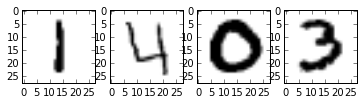

```python
import matplotlib.cm as cm
fig, axes= plt.subplots(1,4)
axes[0].imshow(reshaped[1], cmap = cm.gist_yarg);
axes[1].imshow(reshaped[2], cmap = cm.gist_yarg);
axes[2].imshow(reshaped[3], cmap = cm.gist_yarg);
axes[3].imshow(reshaped[8], cmap = cm.gist_yarg);
```

We can see that there is a fair bit of variation in the style of writing, as we would expect.

To get an idea of what the average digit looks like, let's plot the average digit as above.

We can see that many of the digits have weaker averages than others. In particular, 4 and 5 don't have very many darker black regions, which means that those digits don't have as consistent averages.

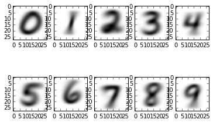

## Image Processing considerations

Before we move on to fitting some models, I'm going to consider some image processing methods we can use to clean our data.

**Darker backgrounds**

In algorithms like KNN, we could suffer from the curse of dimensionality, especially because of the distance that edge pixels have relative to internal pixels. We can "reduce" this by darkening the background to a higher shade of grey. This is a delicate process because we do not want to lose information.

If we can find a good way to bring the always white pixels to higher grey values, we will in some sense *compact* the space a little bit, without losing information about the digit. This will help algorithms such as KNN

With that in mind, we will try using a values of 25 on pixels that are nearly always 0 (Which can be found from averages above). This will also include values that are less than 1 (Since that an average pixel value less than 1 is insignificant). If this gives us an improvement, I will consider tuning the value further.

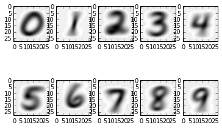

**Averaging - Dimension Reduction**

Another possibility is some simple dimension reduction. We can partition the pixels in to 196 2x2 squares and average them together to produce a 14x14 pixel image. A reduction in dimensionality should help KNN and definitely offere benefits to Neural Networks.

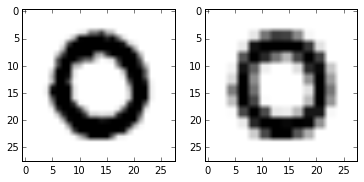

```python
fig, axes = plt.subplots(1,2)
axes[0].imshow(images.loc[1].values[1:].reshape(28,28), cmap = cm.gist_yarg)
axes[1].imshow(newDF.loc[1][1:].reshape(28,28), cmap = cm.gist_yarg)
```

## Models

### Using straight data, with no image processing:

**KNN Classification**

I chose this because I felt that it would be a not bad first attempt at classification. I used 10 Stratified K-Folds, because the data set is large, and I'm not too concerned with computation time.

Using the default KNN with n = 1,3,5,7,9,11 and 13, the average 10 fold cross validation scores

0.967380872089 n_neighbors=1

0.968261003894 n_neighbors=3

0.967332930741 n_neighbors=5

0.966428677921 n_neighbors=7

0.965118597957 n_neighbors=9

0.963475422204 n_neighbors=11

0.962142297907 n_neighbors=13

We can see that using simply the default settings (and a whole night of computation) that KNN does a really good job of classifying this problem. The curse of dimensionality is avoided because of how similar the pixel values are within a particular digit. We can see this when viewing the averages.

Now, let's choose our best KNN (k=3) and run it using identical settings on the darker background dataset and see if things are improved.

```
0.970261003894KNeighborsClassifier(algorithm='auto', leaf_size=30, metric='minkowski',metric_params=None, n_neighbors=3, p=2, weights='uniform')
```

We can see that the darker background offered a slight improvement for KNN.

**Simple Multilayer perceptron**

The NeuralNet uses a test/train split, but we include a dropout layer to avoid overfitting. As a first simple example, let's train a single hidden layer neural network. We will use a lower number of hidden units, and a lower drop out probability so that we can get a general idea of how well multilayer perceptron performs on our problem.

I'm using a library called lasagne, which implements a really easy to use neural network interface, with full control of the parameters.

```python
fc_1hidden = NeuralNet(
    layers = [
        ('input', layers.InputLayer),
        ('hidden', layers.DenseLayer),
        ('dropout', layers.DropoutLayer),
        ('output', layers.DenseLayer),
        ],
    input_shape = (None, 784), #28x28
    hidden_num_units = 200,
    dropout_p = 0.25, # dropout probability
    output_nonlinearity = softmax,
    output_num_units = 10,

    update = sgd, #Gradient descent
    update_learning_rate = 0.001,

    eval_size = 0.1,
    max_epochs = 100,
    verbose = 1,
    )

fc_1hidden.fit(train_data, train_label)
```

```
train: (42000L, 784L) (42000L,)
  InputLayer        	(None, 784)         	produces     784 outputs
  DenseLayer        	(None, 200)         	produces     200 outputs
  DropoutLayer      	(None, 200)         	produces     200 outputs
  DenseLayer        	(None, 10)          	produces      10 outputs

 Epoch  |  Train loss  |  Valid loss  |  Train / Val  |  Valid acc  |  Dur
--------|--------------|--------------|---------------|-------------|-------
     1  |    6.365945  |    1.141520  |     5.576726  |     75.67%  |  1.6s
     2  |    1.132628  |    0.803935  |     1.408855  |     81.68%  |  1.6s
     3  |    0.875683  |    0.672521  |     1.302090  |     85.05%  |  1.6s
     4  |    0.735166  |    0.615737  |     1.193961  |     85.20%  |  1.6s
     5  |    0.653918  |    0.538908  |     1.213414  |     87.32%  |  1.5s
     6  |    0.594566  |    0.510266  |     1.165207  |     87.83%  |  1.6s
     7  |    0.550036  |    0.478399  |     1.149743  |     88.44%  |  1.6s
```

[output cut: 93 more lines]

```
NeuralNet(X_tensor_type=<function matrix at 0x00000000129E1AC8>,
     batch_iterator_test=<nolearn.lasagne.BatchIterator object at 0x0000000012F672B0>,
     batch_iterator_train=<nolearn.lasagne.BatchIterator object at 0x0000000012F67C50>,
     dropout_p=0.25, eval_size=0.1, hidden_num_units=200,
     input_shape=(None, 784),
     layers=[('input', <class 'lasagne.layers.input.InputLayer'>), ('hidden', <class 'lasagne.layers.dense.DenseLayer'>), ('dropout', <class 'lasagne.layers.noise.DropoutLayer'>), ('output', <class 'lasagne.layers.dense.DenseLayer'>)],
     loss=<function negative_log_likelihood at 0x00000000171B9588>,
     max_epochs=100, more_params={}, on_epoch_finished=(),
     on_training_finished=(),
     output_nonlinearity=<theano.tensor.nnet.nnet.Softmax object at 0x00000000161CE400>,
     output_num_units=10, regression=False,
     update=<function sgd at 0x00000000171B9278>,
     update_learning_rate=0.001, use_label_encoder=False, verbose=1,
     y_tensor_type=TensorType(int32, vector))
```

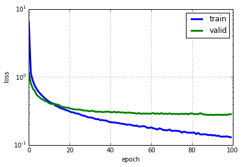

```python
plot_loss(fc_1hidden)
```

Now, let's consider a more complicated neural network. The following network is described in a paper about dropout as a metric for the improvement that dropout can provide.

```python
betterNet= NeuralNet(
    layers = [  # three layers: one hidden layer
        ('input', layers.InputLayer),
        ('hidden1', layers.DenseLayer),
       ('hidden2', layers.DenseLayer),
        ('hidden3', layers.DenseLayer),
        ('dropout', layers.DropoutLayer),
        ('output', layers.DenseLayer),
        ],
    # layer parameters:
    input_shape = (None, 784),  # 28x28 input pixels per batch
    hidden1_num_units = 1024,  # number of units in hidden layer
    hidden2_num_units = 1024,
    hidden3_num_units = 1024,
    dropout_p = 0.4, # dropout probability
    output_nonlinearity = softmax,  # output layer uses softmax function
    output_num_units = 10,  # 10 labels

    # optimization method:
    #update = nesterov_momentum,
    update = sgd,
    update_learning_rate = 0.001,
    #update_momentum = 0.9,

    eval_size = 0.1,

    # batch_iterator_train = BatchIterator(batch_size = 20),
    # batch_iterator_test = BatchIterator(batch_size = 20),

    max_epochs = 100,  # we want to train this many epochs
    verbose = 1,
    )

betterNet.fit(train_data, train_label)
```

```
train: (42000L, 784L) (42000L,)
  InputLayer        	(None, 784)         	produces     784 outputs
  DenseLayer        	(None, 1024)        	produces    1024 outputs
  DenseLayer        	(None, 1024)        	produces    1024 outputs
  DenseLayer        	(None, 1024)        	produces    1024 outputs
  DropoutLayer      	(None, 1024)        	produces    1024 outputs
  DenseLayer        	(None, 10)          	produces      10 outputs

 Epoch  |  Train loss  |  Valid loss  |  Train / Val  |  Valid acc  |  Dur
--------|--------------|--------------|---------------|-------------|-------
     1  |    4.605754  |    0.516463  |     8.917878  |     92.61%  |  27.1s
     2  |    0.570223  |    0.348431  |     1.636547  |     93.99%  |  27.2s
     3  |    0.347593  |    0.295226  |     1.177377  |     94.46%  |  26.5s
     4  |    0.252081  |    0.261326  |     0.964621  |     94.79%  |  26.8s
     5  |    0.190673  |    0.251087  |     0.759391  |     94.78%  |  27.1s
```

[output cut: 95 more lines]

```
NeuralNet(X_tensor_type=<function matrix at 0x00000000129E1AC8>,
     batch_iterator_test=<nolearn.lasagne.BatchIterator object at 0x0000000012F672B0>,
     batch_iterator_train=<nolearn.lasagne.BatchIterator object at 0x0000000012F67C50>,
     dropout_p=0.4, eval_size=0.1, hidden1_num_units=1024,
     hidden2_num_units=1024, hidden3_num_units=1024,
     input_shape=(None, 784),
     layers=[('input', <class 'lasagne.layers.input.InputLayer'>), ('hidden1', <class 'lasagne.layers.dense.DenseLayer'>), ('hidden2', <class 'lasagne.layers.dense.DenseLayer'>), ('hidden3', <class 'lasagne.layers.dense.DenseLayer'>), ('dropout', <class 'lasagne.layers.noise.DropoutLayer'>), ('outpu…
     loss=<function negative_log_likelihood at 0x00000000171B9588>,
     max_epochs=100, more_params={}, on_epoch_finished=(),
     on_training_finished=(),
     output_nonlinearity=<theano.tensor.nnet.nnet.Softmax object at 0x00000000161CE400>,
     output_num_units=10, regression=False,
     update=<function sgd at 0x00000000171B9278>,
     update_learning_rate=0.001, use_label_encoder=False, verbose=1,
     y_tensor_type=TensorType(int32, vector))
```

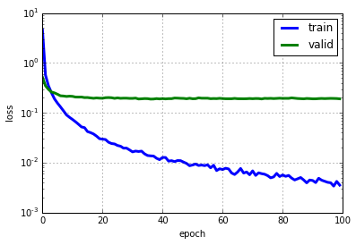

```python
plot_loss(betterNet)
```

We can see that using more hidden layers can produce a better result. Using more units in each hidden layer can also improve our model, but it increases the computation time quite a bit. That being said, there's a high chance that we are overfitting the model here, since the validation accuracy levels out.

An important consideration when tuning a neural network is the dropout probability. Using more units in each layer increases the need for a higher drop out probability, because we have more models to approximate.

**Image Processed variants**

Let's train the same neural networks on the image processed data sets.

First the darkened background.

```python
train_label = darkened['label']
train_data = darkened.drop('label', axis = 1)
print "train:", train_data.shape, train_label.shape


train_data = train_data.astype(np.float)
train_label = train_label.astype(np.int32)
train_data, train_label = shuffle(train_data, train_label, random_state = 21)


img = NeuralNet(
    layers = [
        ('input', layers.InputLayer),
        ('hidden', layers.DenseLayer),
        ('dropout', layers.DropoutLayer),
        ('output', layers.DenseLayer),
        ],
    input_shape = (None, 784), #28x28
    hidden_num_units = 200,
    dropout_p = 0.25, # dropout probability
    output_nonlinearity = softmax,
    output_num_units = 10,

    update = sgd, #Gradient descent
    update_learning_rate = 0.001,

    eval_size = 0.1,
    max_epochs = 100,
    verbose = 1,
    )

img.fit(train_data, train_label)
```

```
train: (42000, 784) (42000,)
  InputLayer        	(None, 784)         	produces     784 outputs
  DenseLayer        	(None, 200)         	produces     200 outputs
  DropoutLayer      	(None, 200)         	produces     200 outputs
  DenseLayer        	(None, 10)          	produces      10 outputs

 Epoch  |  Train loss  |  Valid loss  |  Train / Val  |  Valid acc  |  Dur
--------|--------------|--------------|---------------|-------------|-------
     1  |    5.769993  |    0.922568  |     6.254274  |     80.97%  |  1.6s
     2  |    1.037251  |    0.678811  |     1.528042  |     85.40%  |  1.5s
     3  |    0.783200  |    0.567939  |     1.379020  |     87.27%  |  1.4s
     4  |    0.665876  |    0.506996  |     1.313377  |     88.11%  |  1.5s
     5  |    0.598181  |    0.468801  |     1.275979  |     89.43%  |  1.5s
     6  |    0.549403  |    0.446048  |     1.231711  |     89.74%  |  1.4s
     7  |    0.501042  |    0.420222  |     1.192327  |     90.59%  |  1.5s
```

[output cut: 93 more lines]

```
NeuralNet(X_tensor_type=<function matrix at 0x00000000129E1AC8>,
     batch_iterator_test=<nolearn.lasagne.BatchIterator object at 0x0000000012F672B0>,
     batch_iterator_train=<nolearn.lasagne.BatchIterator object at 0x0000000012F67C50>,
     dropout_p=0.25, eval_size=0.1, hidden_num_units=200,
     input_shape=(None, 784),
     layers=[('input', <class 'lasagne.layers.input.InputLayer'>), ('hidden', <class 'lasagne.layers.dense.DenseLayer'>), ('dropout', <class 'lasagne.layers.noise.DropoutLayer'>), ('output', <class 'lasagne.layers.dense.DenseLayer'>)],
     loss=<function negative_log_likelihood at 0x00000000171B9588>,
     max_epochs=100, more_params={}, on_epoch_finished=(),
     on_training_finished=(),
     output_nonlinearity=<theano.tensor.nnet.nnet.Softmax object at 0x00000000161CE400>,
     output_num_units=10, regression=False,
     update=<function sgd at 0x00000000171B9278>,
     update_learning_rate=0.001, use_label_encoder=False, verbose=1,
     y_tensor_type=TensorType(int32, vector))
```

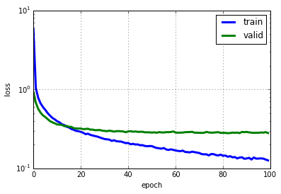

```python
plot_loss(img)
```

The image processed variant with darker backgrounds does slightly better (Not insigificant in terms of the randomness of drop out probability) and learns at a slightly faster rate.

Now the downsampled data set:

```python
ds = NeuralNet(
    layers = [
        ('input', layers.InputLayer),
        ('hidden', layers.DenseLayer),
        ('dropout', layers.DropoutLayer),
        ('output', layers.DenseLayer),
        ],
    input_shape = (None, 196), #14x14
    hidden_num_units = 200,
    dropout_p = 0.25, # dropout probability
    output_nonlinearity = softmax,
    output_num_units = 10,

    update = sgd, #Gradient descent
    update_learning_rate = 0.001,

    eval_size = 0.1,
    max_epochs = 100,
    verbose = 1,
    )

ds.fit(train_data, train_label)
```

```
train: (42003L, 196L) (42003L,)
  InputLayer        	(None, 196)         	produces     196 outputs
  DenseLayer        	(None, 200)         	produces     200 outputs
  DropoutLayer      	(None, 200)         	produces     200 outputs
  DenseLayer        	(None, 10)          	produces      10 outputs

 Epoch  |  Train loss  |  Valid loss  |  Train / Val  |  Valid acc  |  Dur
--------|--------------|--------------|---------------|-------------|-------
     1  |    6.418801  |    1.713579  |     3.745845  |     55.46%  |  0.9s
     2  |    1.884995  |    1.445834  |     1.303742  |     58.76%  |  0.9s
     3  |    1.623570  |    1.373095  |     1.182417  |     57.20%  |  1.1s
     4  |    1.517938  |    1.325237  |     1.145408  |     57.80%  |  1.2s
     5  |    1.439256  |    1.290201  |     1.115528  |     58.43%  |  1.0s
     6  |    1.399981  |    1.274375  |     1.098562  |     59.02%  |  1.0s
     7  |    1.373960  |    1.251504  |     1.097847  |     58.85%  |  1.0s
```

[output cut: 93 more lines]

```
NeuralNet(X_tensor_type=<function matrix at 0x00000000208F3668>,
     batch_iterator_test=<nolearn.lasagne.BatchIterator object at 0x000000001FB8CF60>,
     batch_iterator_train=<nolearn.lasagne.BatchIterator object at 0x000000001FB8CF28>,
     dropout_p=0.25, eval_size=0.1, hidden_num_units=200,
     input_shape=(None, 196),
     layers=[('input', <class 'lasagne.layers.input.InputLayer'>), ('hidden', <class 'lasagne.layers.dense.DenseLayer'>), ('dropout', <class 'lasagne.layers.noise.DropoutLayer'>), ('output', <class 'lasagne.layers.dense.DenseLayer'>)],
     loss=<function negative_log_likelihood at 0x000000001FB97438>,
     max_epochs=100, more_params={}, on_epoch_finished=(),
     on_training_finished=(),
     output_nonlinearity=<theano.tensor.nnet.nnet.Softmax object at 0x0000000015F15B70>,
     output_num_units=10, regression=False,
     update=<function sgd at 0x0000000018A1ED68>,
     update_learning_rate=0.001, use_label_encoder=False, verbose=1,
     y_tensor_type=TensorType(int32, vector))
```

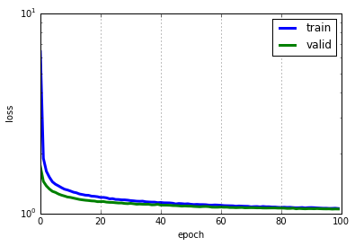

```python
plot_loss(ds)
```

Let us now move to a convolutional neural network. Let's start with two convolutional layers, and one hidden layer (With dropout of course!)

```
train: (42000L, 784L) (42000L,)
  InputLayer        	(None, 1, 28, 28)   	produces     784 outputs
  Conv2DLayer       	(None, 32, 26, 26)  	produces   21632 outputs
  MaxPool2DLayer    	(None, 32, 13, 13)  	produces    5408 outputs
  DropoutLayer      	(None, 32, 13, 13)  	produces    5408 outputs
  Conv2DLayer       	(None, 64, 12, 12)  	produces    9216 outputs
  MaxPool2DLayer    	(None, 64, 6, 6)    	produces    2304 outputs
  DropoutLayer      	(None, 64, 6, 6)    	produces    2304 outputs
  DenseLayer        	(None, 500)         	produces     500 outputs
  DropoutLayer      	(None, 500)         	produces     500 outputs
  DenseLayer        	(None, 10)          	produces      10 outputs

 Epoch  |  Train loss  |  Valid loss  |  Train / Val  |  Valid acc  |  Dur
--------|--------------|--------------|---------------|-------------|-------
     1  |   15.614187  |    1.663984  |     9.383618  |     60.79%  |  420.3s
```

[output cut: 48 more lines]

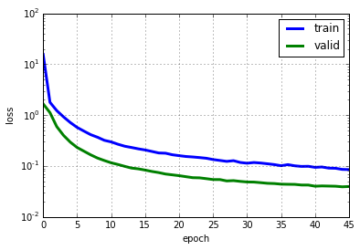

```python
cnn = NeuralNet(
    layers = [  # three layers: one hidden layer
        ('input', layers.InputLayer),

        ('conv1', Conv2DLayer),
        ('pool1', MaxPool2DLayer),
        ('dropout1', layers.DropoutLayer),

        ('conv2', Conv2DLayer),
        ('pool2', MaxPool2DLayer),
        ('dropout2', layers.DropoutLayer),

        ('hidden4', layers.DenseLayer),
        ('dropout4', layers.DropoutLayer),

        ('output', layers.DenseLayer),
        ],
    # layer parameters:
    input_shape = (None, 1, 28, 28),  # 28x28 input pixels per batch

    conv1_num_filters = 32, conv1_filter_size = (3, 3), pool1_ds = (2, 2), dropout1_p = 0.5,
    conv2_num_filters = 64, conv2_filter_size=(2, 2), pool2_ds=(2, 2), dropout2_p = 0.5,
    conv3_num_filters = 128, conv3_filter_size = (2, 2), pool3_ds = (2, 2), dropout3_p = 0.5,

    hidden4_num_units = 500, dropout4_p = 0.5,

    output_num_units = 10,  # 10 labels

    conv1_nonlinearity = rectify, conv2_nonlinearity = rectify, conv3_nonlinearity = rectify,
    hidden4_nonlinearity = rectify,
    output_nonlinearity = softmax,  # output layer uses softmax function

    # optimization method:
    #update = adagrad,
    update = rmsprop,
    update_learning_rate = 0.0001,
    #update_learning_rate = 0.01,

    eval_size = 0.1,

    max_epochs = 200,  # we want to train this many epochs
    verbose = 1,
    )

cnn.fit(train_data, train_label)
plot_loss(cnn)
```

With the Convolutional NN we can see that despite its extremely expensive computation, it does an excellent job, even though it's underfitting. (Since Train/Validation loss >1). To fully convince myself of the fit, I made a submission to Kaggle and scored 98.11% placing me 56th on the leaderboard at the time of writing, which is pretty good.

# Classifying REAL Handwritten Digits

Using my artistically inclined friend with a drawing tablet, I produced a small set of handwritten digits that I then converted to the same format as the MNIST data. It is worth noting that I did not apply the exact transformations of the data (20x20 centered on a 28x28 grid). These are the results.

The first class is using a soft brush to produce a similar antialiasing effect to the original

```
Prediction accuracy on homemade digits :43.3333333333
```

Below is the score on a hard brush, which has no antialiasing

```
Prediction accuracy on homemade digits :50.0
```

I'm not sure why the cnn performed so poorly. I think the reason could lie in the semi-complicated process that gets applied to the MNIST data. Using a soft brush is not equivalent to antialiasing hard brush images. Also the image's center of mass is calculated and centered on a grid.

The hand drawn images are just drawn in Photoshop on a 28x28 grid. There's also a few hard digits, like klaxon 0s and strange looking 1s.

References

Useful code snippets: http://danielnouri.org/notes/2014/12/17/using-convolutional-neural-nets-to-detect-facial-keypoints-tutorial/

1-hidden-layer MLP Mathematical definition - http://deeplearning.net/tutorial/mlp.html

Theano - http://deeplearning.net/software/theano/

Lasagne - http://lasagne.readthedocs.org/en/latest/

Nolearn - https://pythonhosted.org/nolearn/